# Decision Tree (Python, Recording data)

# Tree 2

## Visualization

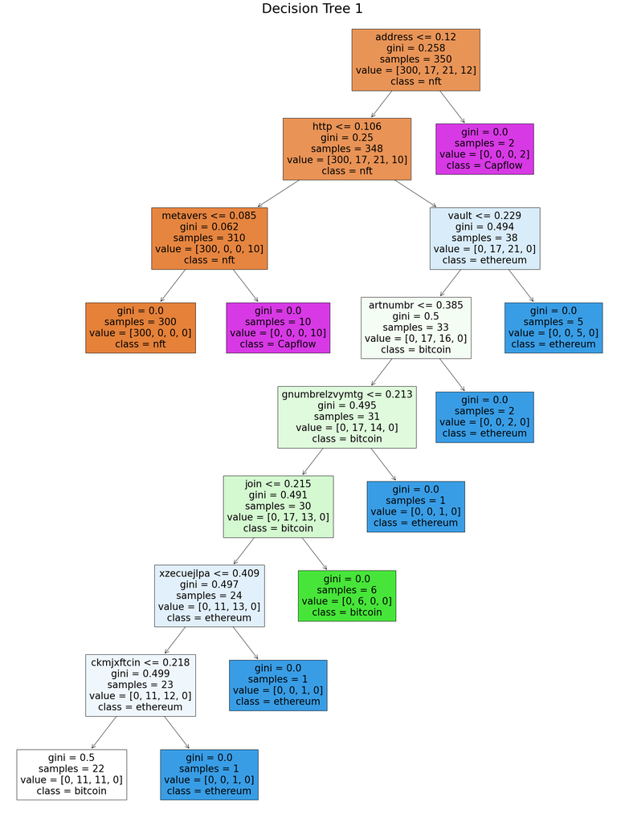

```python
## Instantiate
MyDT=DecisionTreeClassifier(criterion='gini', ##"entropy" or "gini"
                            splitter='best',  ## or "random" or "best"
                            max_depth=8,
                            min_samples_split=2,
                            min_samples_leaf=1,
                            min_weight_fraction_leaf=0.0,
                            max_features=10,
                            random_state=1,
                            max_leaf_nodes=None,
                            min_impurity_decrease=0.0,
#                             min_impurity_split=None,
                            class_weight=None)

##
MyDT.fit(train_data, train_label)


feature_names=train_data.columns
topics = ori_data['topic'].unique()

fig = plt.figure(figsize=(30,40))
_ = tree.plot_tree(MyDT,
                   feature_names = feature_names,
                   class_names=topics,
                   filled=True)
plt.title("Decision Tree 1", fontsize = 36)
# fig.savefig("decistion_tree1.png")
```

## Confusion matrix

```python
DT_pred=MyDT.predict(test_data)

Accuracy_score=accuracy_score(test_label,DT_pred)
print("The Accuracy Score is:")
print(Accuracy_score)

bn_matrix = confusion_matrix(test_label, DT_pred)
print("\nThe confusion matrix is:")
print(bn_matrix)
```

```
The Accuracy Score is:
0.94

The confusion matrix is:
[[132   0   0]
 [  0   8   0]
 [  0   9   1]]
```

## Key features

```python
FeatureImp=MyDT.feature_importances_
indices = np.argsort(FeatureImp)[::-1]
## print out the important features.....
for f in range(train_data.shape[1]):
    if FeatureImp[indices[f]] > 0:
        print("%d. feature %d (%f)" % (f + 1, indices[f], FeatureImp[indices[f]]))
        print ("feature name: ", feature_names[indices[f]])
```

```
1. feature 221 (0.645935)
feature name:  http
2. feature 309 (0.255926)
feature name:  metavers
3. feature 6 (0.044505)
feature name:  address
4. feature 642 (0.030474)
feature name:  vault
5. feature 20 (0.014942)
feature name:  artnumbr
6. feature 180 (0.008218)
feature name:  gnumbrelzvymtg
```

## Discussion and analysis

Decision tree 2 sets several parameters compared with the previous one. In this tree, GINI criteria are used rather than cross-entropy. Then, to avoid overfitting, "max_depth" is set to be 8.

Compared with the previous reasonable important features, important features in this decision tree starts to give more importance score on some unique words.

# Tree 3

## Visualization

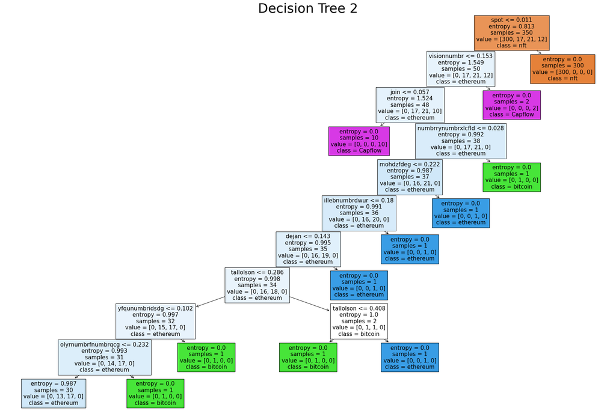

```python
## Instantiate
MyDT=DecisionTreeClassifier(criterion='entropy', ##"entropy" or "gini"
                            splitter='random',  ## or "random" or "best"
                            max_depth=10,
                            min_samples_split=2,
                            min_samples_leaf=1,
                            min_weight_fraction_leaf=0.0,
                            max_features=30,
                            random_state=2,
                            max_leaf_nodes=None,
                            min_impurity_decrease=0.0,
#                             min_impurity_split=None,
                            class_weight=None)

##
MyDT.fit(train_data, train_label)

feature_names=train_data.columns
topics = ori_data['topic'].unique()

fig = plt.figure(figsize=(30,20))
_ = tree.plot_tree(MyDT,
                   feature_names = feature_names,
                   class_names=topics,
                   filled=True)
plt.title("Decision Tree 2", fontsize = 36)
# fig.savefig("decistion_tree1.png")
```

## Confusion matrix

```python
DT_pred=MyDT.predict(test_data)

Accuracy_score=accuracy_score(test_label,DT_pred)
print("The Accuracy Score is:")
print(Accuracy_score)


bn_matrix = confusion_matrix(test_label, DT_pred)
print("\nThe confusion matrix is:")
print(bn_matrix)
```

```
The Accuracy Score is:
0.9466666666666667

The confusion matrix is:
[[132   0   0]
 [  0   0   8]
 [  0   0  10]]
```

## Key features

```python
FeatureImp=MyDT.feature_importances_
indices = np.argsort(FeatureImp)[::-1]
## print out the important features.....
for f in range(train_data.shape[1]):
    if FeatureImp[indices[f]] > 0:
        print("%d. feature %d (%f)" % (f + 1, indices[f], FeatureImp[indices[f]]))
        print ("feature name: ", feature_names[indices[f]])
```

```
1. feature 591 (0.812358)
feature name:  spot
2. feature 251 (0.139015)
feature name:  join
3. feature 648 (0.016924)
feature name:  visionnumbr
4. feature 604 (0.007866)
feature name:  tallolson
5. feature 427 (0.004647)
feature name:  numbrrynumbrxlcfld
6. feature 487 (0.004614)
feature name:  olyrnumbrfnumbrqcg
7. feature 708 (0.004392)
feature name:  yfqunumbridsdg
8. feature 94 (0.003527)
feature name:  dejan
9. feature 230 (0.003391)
feature name:  illebnumbrdwur
10. feature 315 (0.003265)
feature name:  mohdzfdeg
```

## Discussion and analysis

By setting the "splitter='random'" and "max_features=30,", the decision tree model perform a high prediction. The fewer max features increased the randomness of the model tree. This time, by enlarging the max features, the tree becomes more stable than the previous two trees.

# Summary

## Conclusion 2

**The boundary between different topics becomes clear although they arose from the same starting.** In this project, the main reason why tree decision trees achieve a high precision is because of the distinctive different keywords between different topics. For example, when talking about the NFT, almost all the tweets are discussing a few keywords: airdrop, join, and play, where these keywords nearly are not discussed in other topics. Beyond that, due to the highly concentrated keywords, this gives a good opportunity for the decision tree to achieve such high precision. Therefore, some deeper work can be done on how to classify the tweets, especially in this area.